# Group 2 Assignment 3

Hotel & Resort Cancellations

Jennifer Bercera

Kristina Diaz-Kerkado

Megan Marsh

Matt McGehee

Jegg Ononiewu

## Data Description

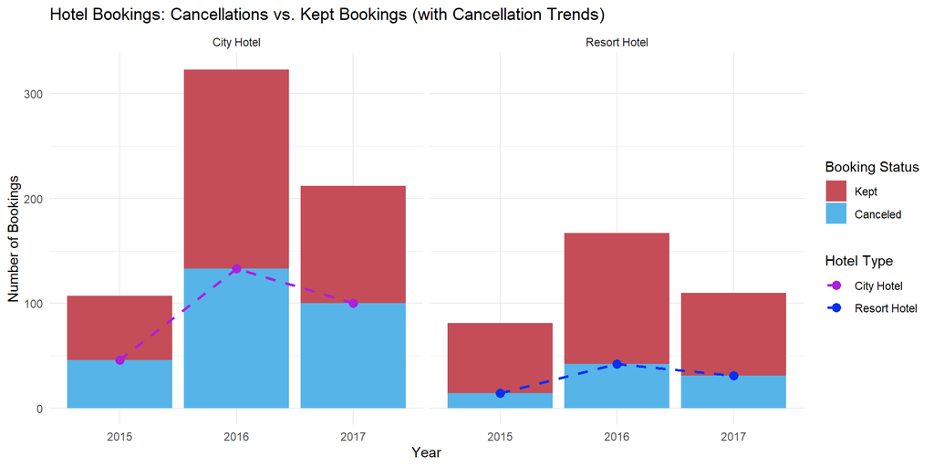

## Hotel Bookings

- Data
- Prior
- Posterior
- Prior vs Posterior
- Thoughts

City Hotel Cancellations

| Year | Total Bookings | Total Cancellations | Cancellation Rate |
| --- | --- | --- | --- |
| 2015 | 107 | 46 | 43.0% |
| 2016 | 323 | 133 | 41.2% |
| 2017 | 212 | 100 | 47.2% |
| Total | 642 | 279 | 43.5% |

After reading an article on city hotel cancellations, calling multiple hotels in the city, and our own personal histories, we held a prior belief that about 40% percent of bookings get cancelled.

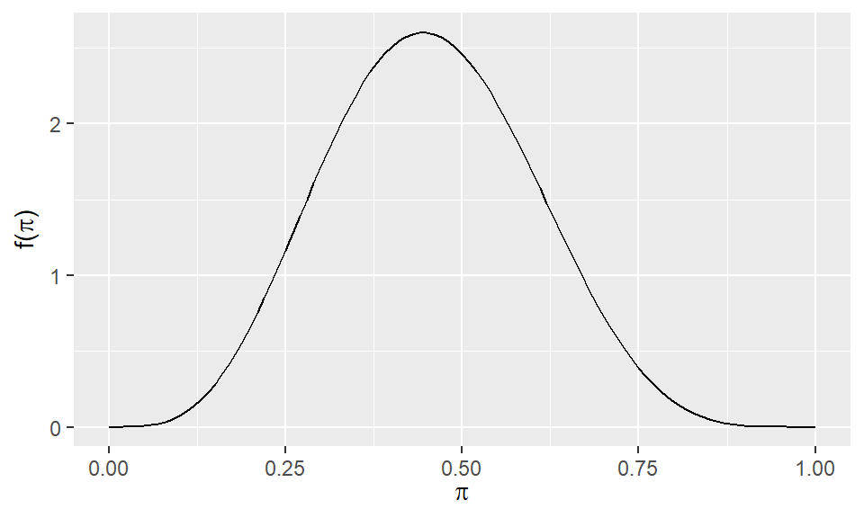

$$\begin{aligned}
\pi \mid (Y = y) &\sim \text{Beta}(\alpha + y, \beta + n - y) \\
\pi \mid (Y = 279) &\sim \text{Beta}(5 + 279, 6 + 642 - 279) \\
\pi \mid (Y = 279) &\sim \text{Beta}(284, 369)
\end{aligned}$$

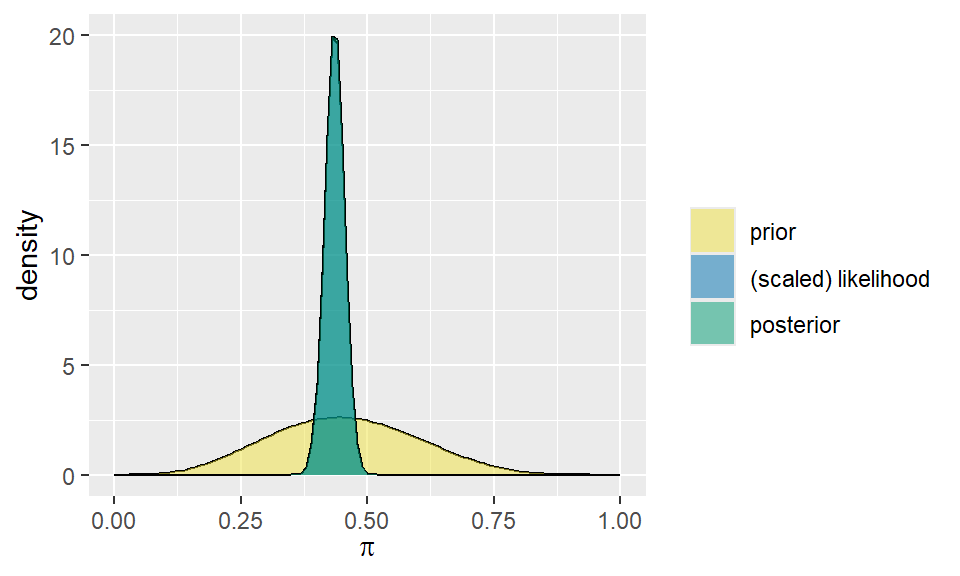

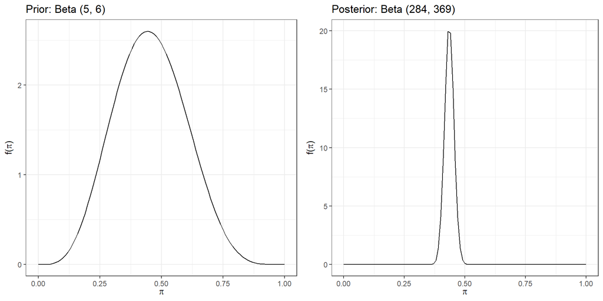

## Resort Bookings

- Data
- Prior
- Posterior
- Prior vs Posterior
- Thoughts

Resort Hotel Cancellations

| Year | Total Bookings | Total Cancellations | Cancellation Rate |
| --- | --- | --- | --- |
| 2015 | 81 | 14 | 17.3% |
| 2016 | 167 | 42 | 25.1% |
| 2017 | 110 | 31 | 28.2% |
| Total | 358 | 87 | 24.3% |

After reading an article on resort cancellations and our own personal histories, we held a prior belief that about 20% percent of bookings get cancelled.

$$\begin{aligned}
E[\pi] &= \frac{\alpha}{\alpha + \beta} = 0.20 \\
\alpha &= 0.20 \times (\alpha + \beta) \\
\beta &= (1 - 0.20) \times (\alpha + \beta) \\
&= 0.80 \times (\alpha + \beta)
\end{aligned}$$

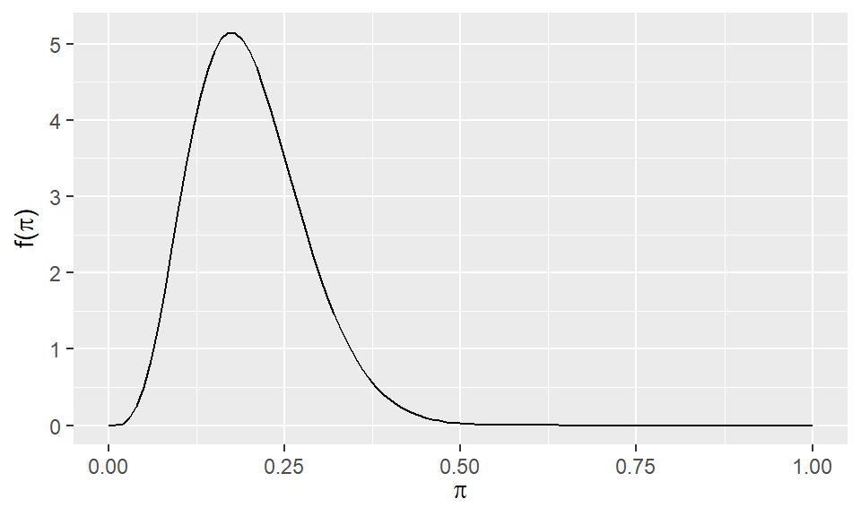

$$\begin{aligned}
\pi \mid (Y = y) &\sim \text{Beta}(\alpha + y, \beta + n - y) \\
\pi \mid (Y = 87) &\sim \text{Beta}(5 + 87, 20 + 358 - 87) \\
\pi \mid (Y = 87) &\sim \text{Beta}(92, 291)
\end{aligned}$$

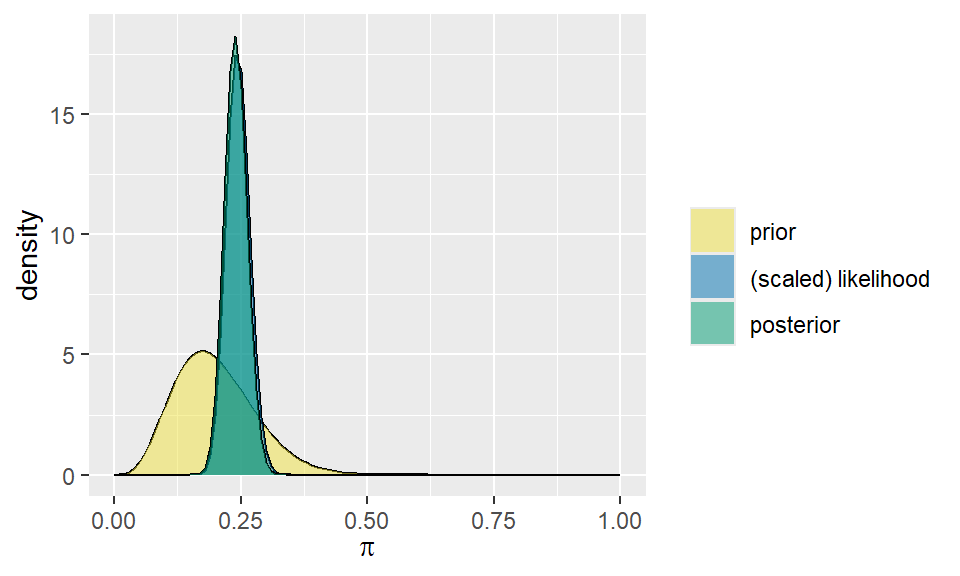

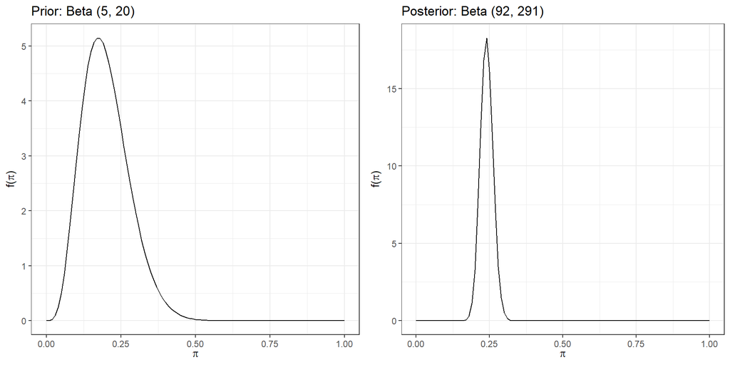

- Initially assumed **Beta(1,1)** (complete uncertainty).
- After research, believed cancellations were **low** (~20%):

$$E[\pi] = \frac{\alpha}{\alpha + \beta} = 0.20$$

- Set weak prior: ($\alpha + \beta = 25$) (low confidence).
- Likelihood dominated posterior due to large data influence.

## Combined Resort and Hotel Bookings

- Data
- Beliefs
- Prior
- Likliehood
- Resort Comparison
- City Comparison

Resort Hotel Cancellations

| Year | Total Bookings | Total Cancellations | Cancellation Rate |
| --- | --- | --- | --- |
| 2015 | 81 | 14 | 17.3% |
| 2016 | 167 | 42 | 25.1% |
| 2017 | 110 | 31 | 28.2% |
| Total | 358 | 87 | 24.3% |

City Hotel Cancellations

| Year | Total Bookings | Total Cancellations | Cancellation Rate |
| --- | --- | --- | --- |
| 2015 | 107 | 46 | 43.0% |
| 2016 | 323 | 133 | 41.2% |
| 2017 | 212 | 100 | 47.2% |
| Total | 642 | 279 | 43.5% |

Based on research and past data trends, we establish the following prior beliefs for cancellation rates: Resort Hotels: We assume a prior cancellation rate of 20% based on industry trends and historical data, as resort bookings tend to be more stable due to vacation planning and reservations. City Hotels: We assume a higher prior cancellation. rate of 30%, given the more dynamic nature of city travel, business trip adjustments, and shorter booking windows, leading to increased. cancellations.

**Resort**
$$\begin{aligned}
E[\pi] &= \frac{\alpha}{\alpha + \beta} = 0.20 \\
\alpha &= 0.20 \times (\alpha + \beta) \\
\beta &= (1 - 0.20) \times (\alpha + \beta) \\
&= 0.80 \times (\alpha + \beta)
\end{aligned}$$

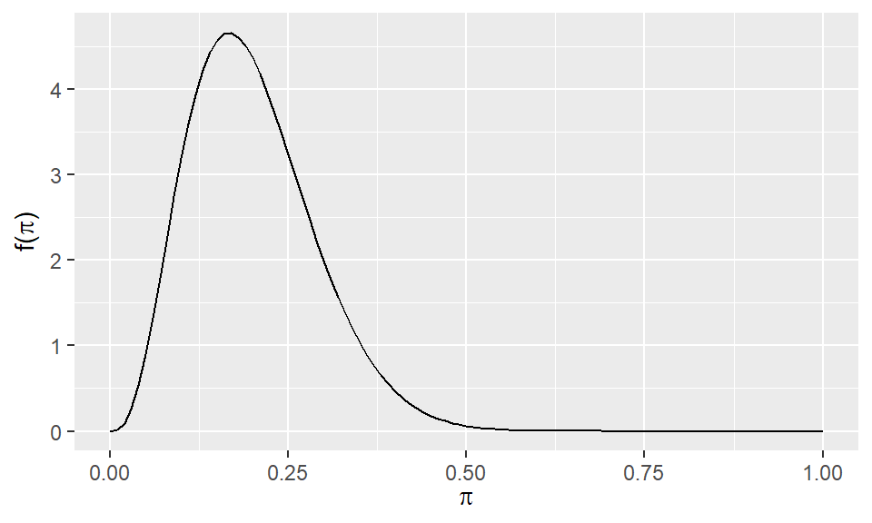

**City**
$$\begin{aligned}
E[\pi] &= \frac{\alpha}{\alpha + \beta} = 0.30 \\
\alpha &= 0.30 \times (\alpha + \beta) \\
\beta &= (1 - 0.30) \times (\alpha + \beta) \\
&= 0.70 \times (\alpha + \beta)
\end{aligned}$$

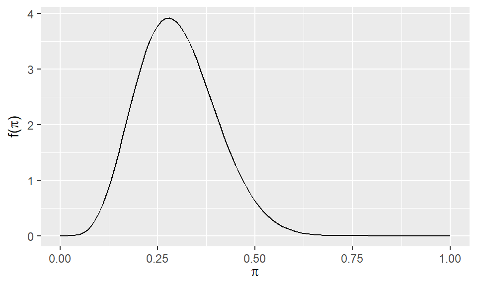

**Resort**
$$\begin{aligned}
\pi \mid (Y = y) &\sim \text{Beta}(\alpha + y, \beta + n - y) \\
\pi \mid (Y = 87) &\sim \text{Beta}(4 + 87, 16 + 358 - 87) \\
\pi \mid (Y = 87) &\sim \text{Beta}(91, 287)
\end{aligned}$$

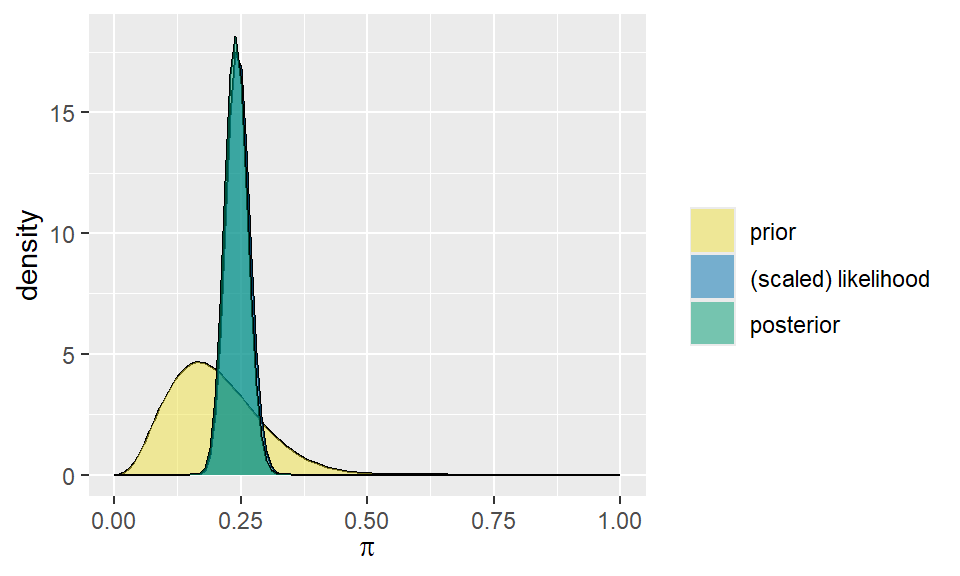

[figure not shown]

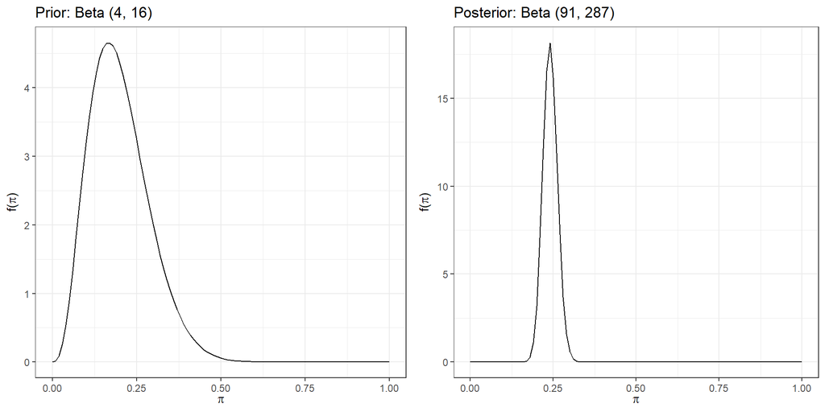

[figure not shown]

## Posterior Models - Comparison

| Booking Type | Posterior Summary |
| --- | --- |
| **Hotel** | $\theta_{\text{hotel}} \sim \text{Beta}(284,\ 369)$ $\mathbb{P}(0.40 \leq \theta_{\text{hotel}} \leq 0.47) \approx 0.95$ |
| **Resort** | $\theta_{\text{resort}} \sim \text{Beta}(92,\ 291)$ $\mathbb{P}(0.20 \leq \theta_{\text{resort}} \leq 0.28) \approx 0.95$ |

- The likely cancellation rate for hotels is around double that of resorts.
- Furthermore, the posterior models closely align with the observed cancellation trends in the data, likely due to:
  - the number of data observations dominating weak prior beliefs,
  - strong prior beliefs closely aligning with the data, or
  - a combination of both.

## MCMC - Resorts

- Trace Plot
- MC Histogram
- MC Density
- MC ACF
- Summary

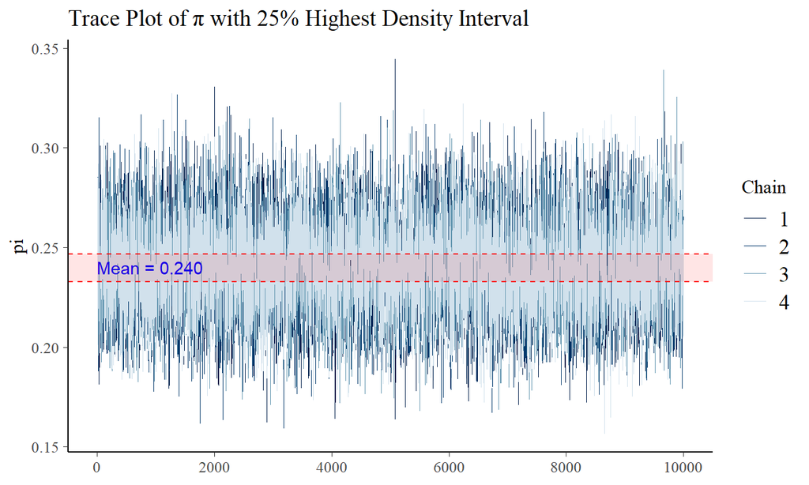

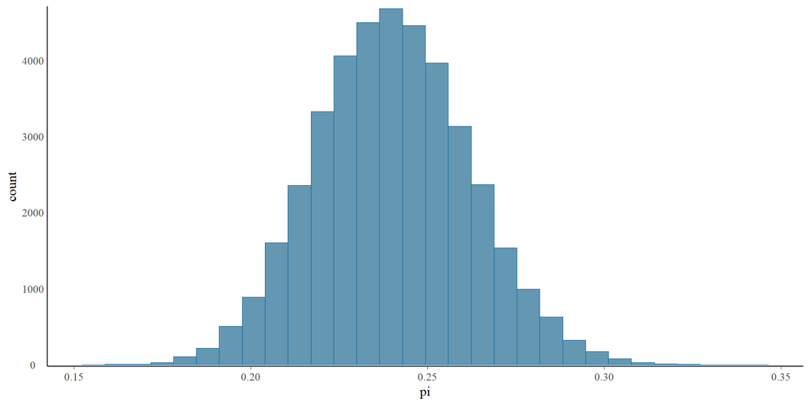

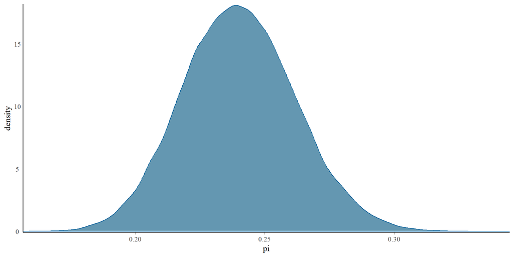

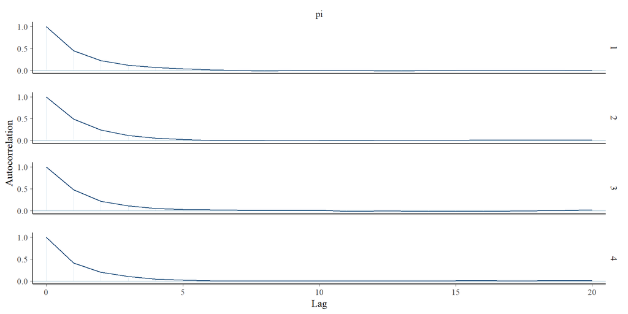

Posterior Summary for π

|  | mean | 25% | 50% | 75% | n_eff | Rhat |
| --- | --- | --- | --- | --- | --- | --- |
| pi | 0.2401 | 0.225 | 0.2397 | 0.2546 | 14348.63 | 1.0003 |